# Introduction to Bayesian Statistics with R

14 May 2024

## Two sample \(t\)-test

Stan

\(\left.\right.\)

We looked at the two-sample \(t\)-test with unequal variance

- Group 1: \(h \sim \mathcal{N}(\mu,\sigma^2)\)
- Group 2: \(h \sim \mathcal{N}(\mu + \beta,\sigma^2 + \gamma)\)

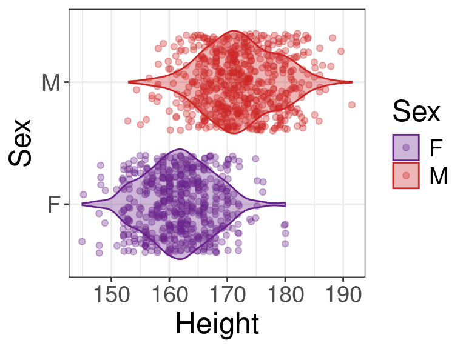

Or more compactly

\[h \sim \mathcal{N}(\mu,\sigma^2)\] with

\[\mu = \beta_0 + \beta_1*\mathrm{Group}\] \[\sigma = \gamma_0 + \gamma_1*\mathrm{Group}\] And brms syntax below

```r
brmfit_t <- brm(bf(Height ~ Sex, sigma ~ Sex), swiss_army_df) # run the model
```

## Robust \(t\)-test

Stan

\(\left.\right.\)

To make the \(t\)-test more robust, model the data with a \(t\)-distribution **Kruschke 2013**

- Group 1: \(h \sim \mathcal{T}_{\nu}(\mu,\sigma^2)\)
- Group 2: \(h \sim \mathcal{T}_{\nu}(\mu + \beta,\sigma^2 + \gamma)\)

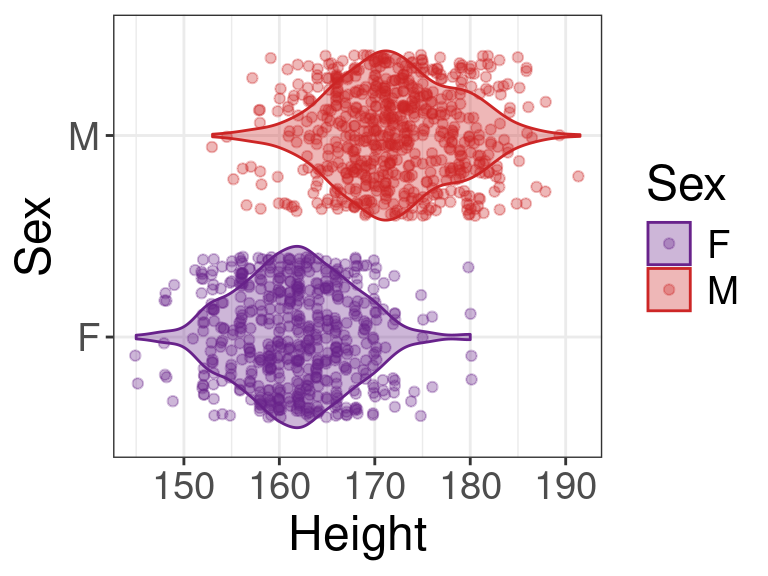

Or more compactly

\[h \sim \mathcal{T}_{\nu}(\mu,\sigma^2)\] with

\[\mu = \beta_0 + \beta_1*\mathrm{Group}\] \[\sigma = \gamma_0 + \gamma_1*\mathrm{Group}\] and the additional parameter \(\nu\)

Just replace the *gaussian* family by *student* in brms

## Robust \(t\)-test in Stan

Stan

Use the *family* argument of brm(…)

```r
brmfit_robust <- brm(bf(Height ~ Sex, sigma ~ Sex), family = student, swiss_army_df) # run the model
summary(brmfit_robust)
```

```
##  Family: student
##   Links: mu = identity; sigma = log; nu = identity
## Formula: Height ~ Sex
##          sigma ~ Sex
##    Data: swiss_army_df (Number of observations: 1160)
##   Draws: 4 chains, each with iter = 2000; warmup = 1000; thin = 1;
##          total post-warmup draws = 4000
##
## Regression Coefficients:
##                 Estimate Est.Error l-95% CI u-95% CI Rhat Bulk_ESS Tail_ESS
## Intercept         161.69      0.25   161.19   162.17 1.00     4927     3087
## sigma_Intercept     1.73      0.03     1.66     1.79 1.00     4037     2993
## SexM               10.46      0.36     9.77    11.17 1.00     4914     3059
## sigma_SexM          0.09      0.04     0.01     0.18 1.00     4415     3165
##
## Further Distributional Parameters:
##    Estimate Est.Error l-95% CI u-95% CI Rhat Bulk_ESS Tail_ESS
## nu    35.83     15.11    15.71    74.95 1.00     3984     3110
##
## Draws were sampled using sampling(NUTS). For each parameter, Bulk_ESS
## and Tail_ESS are effective sample size measures, and Rhat is the potential
## scale reduction factor on split chains (at convergence, Rhat = 1).
```

## Two sample \(t\)-test coefficients

Stan

\(\left.\right.\)

```r
summary(brmfit_robust)$spec_par # extract nu
```

```
##    Estimate Est.Error l-95% CI u-95% CI     Rhat Bulk_ESS Tail_ESS
## nu 35.83432  15.11222 15.71201 74.94859 1.000408 3983.918 3109.709
```

The degree of freedom \(\nu\) is large, so it is close to Gaussian

And very similar CI of interest

```r
fixef(brmfit_robust)["SexM", ] # extract difference in means
```

```
##   Estimate  Est.Error       Q2.5      Q97.5
## 10.4571815  0.3602709  9.7683959 11.1662585
```

- 95% CI of the Gaussian model

```
##  Estimate      Q2.5     Q97.5
## 10.440498  9.760584 11.121184
```

- 95% CI of the \(t\)-test

```
## [1] -11.151169  -9.750496
## attr(,"conf.level")
## [1] 0.95
```

## Two sample \(t\)-test model comparison

Stan

Compare the predictive checks from the pp_check(…) function

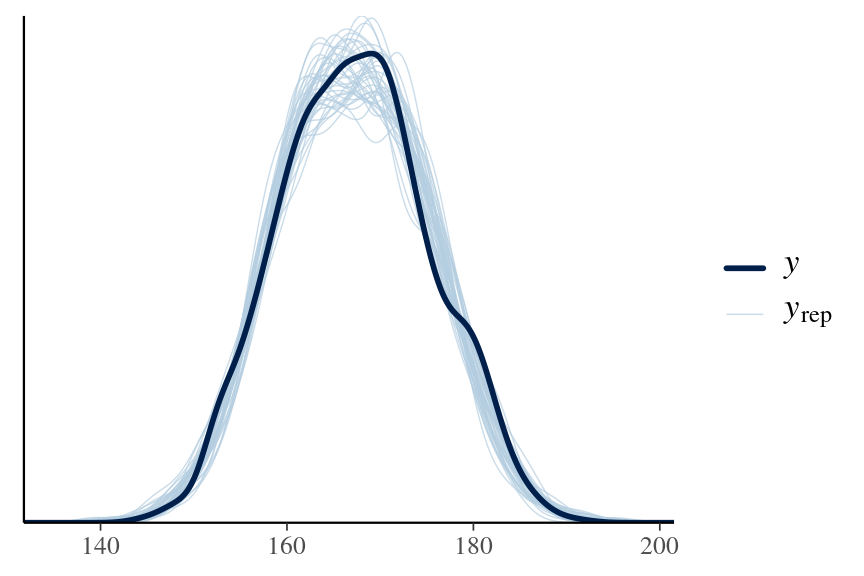

```r
pp_check(brmfit_robust, ndraws = 40)
```

*robust*

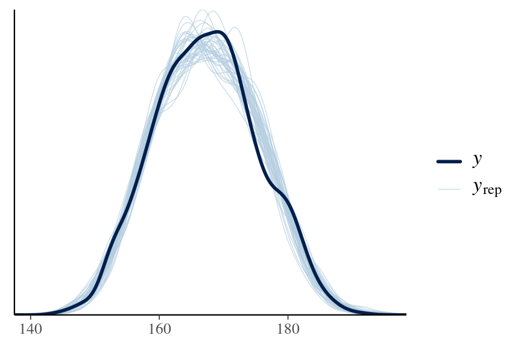

```r
pp_check(brmfit_t, ndraws = 40)
```

*Gaussian*

What have we neglected so far?

## Priors

Stan

The priors! Let’s extract them with the prior_summary(…) function

- The brms defaults are

```r
prior_summary(brmfit_robust)[, -c(4:5, 7)] # hide some columns for display
```

```
##                   prior     class coef  dpar lb ub  source
##                  (flat)         b                  default
##                  (flat)         b SexM             default
##                  (flat)         b      sigma       default
##                  (flat)         b SexM sigma       default
##  student_t(3, 167, 8.2) Intercept                  default
##    student_t(3, 0, 2.5) Intercept      sigma       default
##           gamma(2, 0.1)        nu             1    default
```

- Uniformative for the regression coefficients \(\beta_1\), \(\gamma_1\)
- *Intercepts* are Student-\(t\) with parameters estimated from the data
- *sigma* has a log-link, so its priors are on \(\log(\sigma)\)
- Wide Gamma for \(\nu\) with lower-bound of 1

What should we use?

## Prior selection

It’s an open choice, but we should aim to use information we might know.

- Heights are around 1.6m
- typical variations are tens of cm
- can be below 1m, above 2m

Let’s stick with Student-\(t\) with low degrees of freedom (heavy tails)

- something like student_t(3, 0, 20) for \(\beta_1\)

Variation in sds could be up to a factor 2

- something like student_t(3, 0, 0.5) for \(\gamma_1\) (with the log-link)

Brms syntax:

```r
brmfit_robust_p <- brm(bf(Height ~ Sex, sigma ~ Sex), family = student,
                       prior = prior(student_t(3, 0, 20), class = "b", coef = "SexM") +
                       prior(student_t(3, 0, 0.5), class = "b", coef = "SexM", dpar = "sigma"),
                       swiss_army_df)
```

## Priors

Stan

Check it works with the prior_summary(…) function

- The brms defaults are updated to

```r
prior_summary(brmfit_robust_p)[, -c(4:5, 7)] # hide some columns for display
```

```
##                   prior     class coef  dpar lb ub  source
##                  (flat)         b                  default
##     student_t(3, 0, 20)         b SexM                user
##                  (flat)         b      sigma       default
##    student_t(3, 0, 0.5)         b SexM sigma          user
##  student_t(3, 167, 8.2) Intercept                  default
##    student_t(3, 0, 2.5) Intercept      sigma       default
##           gamma(2, 0.1)        nu             1    default
```

For a visual check we can also sample from the priors

```r
brmfit_robust_prior <- brm(bf(Height ~ Sex, sigma ~ Sex), family = student,
                       prior = prior(student_t(3, 0, 20), class = "b", coef = "SexM") +
                       prior(student_t(3, 0, 0.5), class = "b", coef = "SexM", dpar = "sigma"),
                       sample_prior = "only", swiss_army_df) # this line
```

## Posterior vs Prior

Stan

Compare the posterior and prior samples with the mcmc_plot(…) function

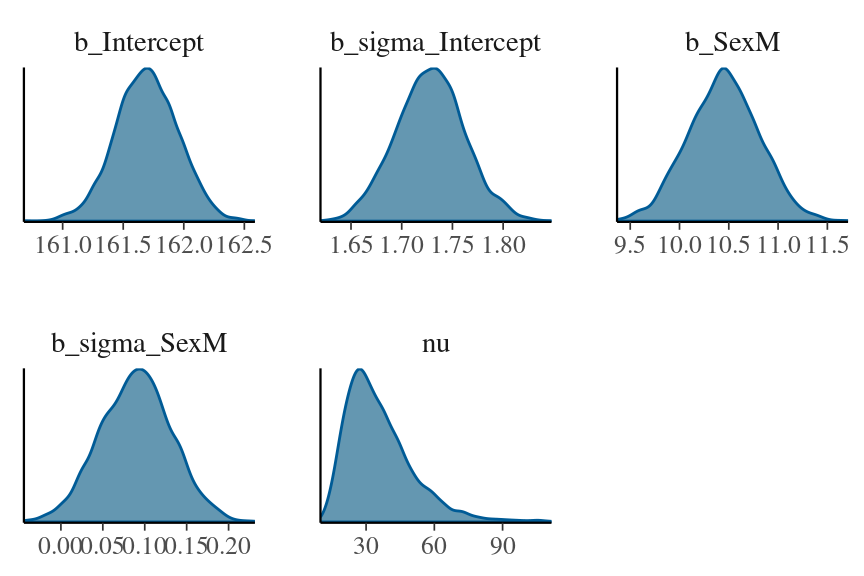

```r
mcmc_plot(brmfit_robust_p, type = "dens")
```

*posterior*

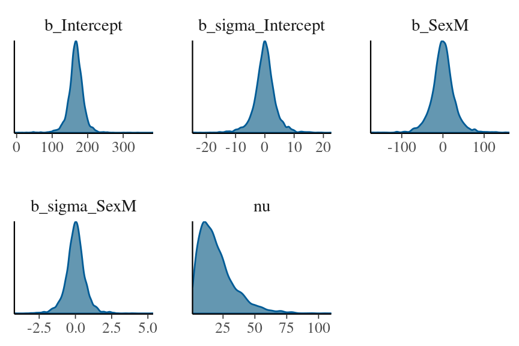

```r
mcmc_plot(brmfit_robust_prior, type = "dens")
```

*prior*

- Posteriors are well inside priors

## Prior predictive check

Stan

Predictive check with the pp_check(…) function

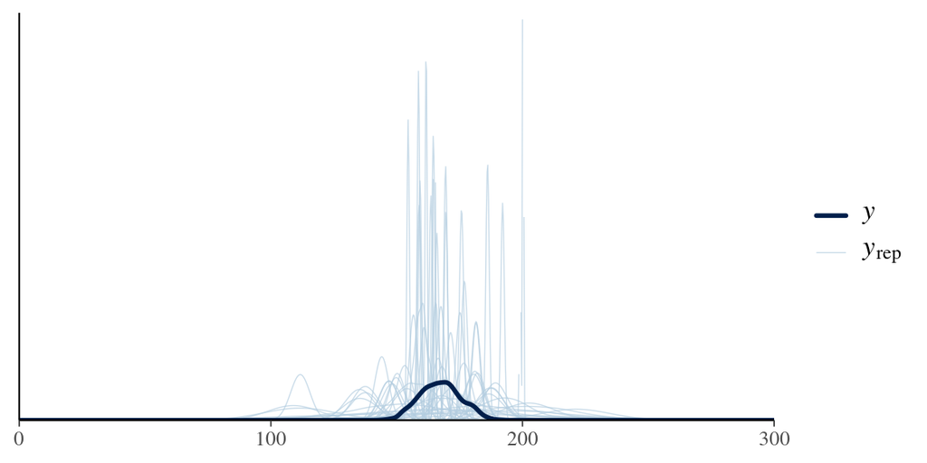

```r
pp_check(brmfit_robust_prior, ndraws = 40) + xlim(0, 300) + ylim(0, 0.5) # plot predictive check
```

since samples are from the prior (in this case)

- data compatible with prior, but too often prior has low sd (hence spikes).

## Updated prior

We wouldn’t expect sds below about 1cm

- simple to impose a lower bound (say 0 with log-link)
- or choose positive distribution (say gamma)

We also might not expect such a large change in sds between conditions

- lower sd for \(\gamma_1\) to student_t(3, 0, 0.2)

```r
brmfit_robust_prior2 <- brm(bf(Height ~ Sex, sigma ~ Sex), family = student,
                        prior = prior(student_t(3, 0, 20), class = "b", coef = "SexM") +
                        prior(student_t(3, 0, 0.2), class = "b", coef = "SexM", dpar = "sigma") + # lower sd
                        prior(student_t(3, 0, 2.5), class = "Intercept", dpar = "sigma", lb = 0), # bound
                        sample_prior = "only", swiss_army_df) # prior samples
```

```r
brmfit_robust_p2 <- brm(bf(Height ~ Sex, sigma ~ Sex), family = student,
                        prior = prior(student_t(3, 0, 20), class = "b", coef = "SexM") +
                        prior(student_t(3, 0, 0.2), class = "b", coef = "SexM", dpar = "sigma") + # lower sd
                        prior(student_t(3, 0, 2.5), class = "Intercept", dpar = "sigma", lb = 0), # bound
                        swiss_army_df) # posterior samples
```

## Priors

Stan

Check it updated with the prior_summary(…) function

```r
prior_summary(brmfit_robust_p2)[, -c(4:5, 7)] # hide some columns for display
```

```
##                   prior     class coef  dpar lb ub  source
##                  (flat)         b                  default
##     student_t(3, 0, 20)         b SexM                user
##                  (flat)         b      sigma       default
##    student_t(3, 0, 0.2)         b SexM sigma          user
##  student_t(3, 167, 8.2) Intercept                  default
##    student_t(3, 0, 2.5) Intercept      sigma  0       user
##           gamma(2, 0.1)        nu             1    default
```

Again we can check samples from the prior

## Prior predictive check

Stan

Predictive check with the pp_check(…) function

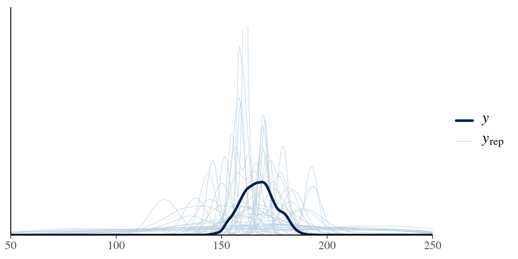

```r
pp_check(brmfit_robust_prior2, ndraws = 40) + xlim(50, 250) + ylim(0, 0.2) # plot predictive check
```

for samples from the updated priors

- have more realistic spreads under the prior.

## Robust t-test

We are interested in regression coefficient \(\beta_1\)

- (b_)SexM in the brms syntax

```r
fixef(brmfit_robust_p2)["SexM", ]
```

```
##   Estimate  Est.Error       Q2.5      Q97.5
## 10.4484567  0.3550322  9.7688574 11.1502971
```

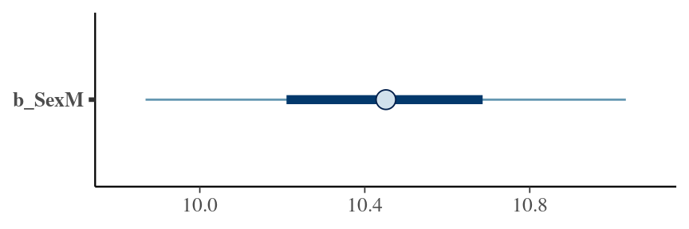

```r
mcmc_plot(brmfit_robust_p2, variable = "b_SexM",
          type = "intervals")
```

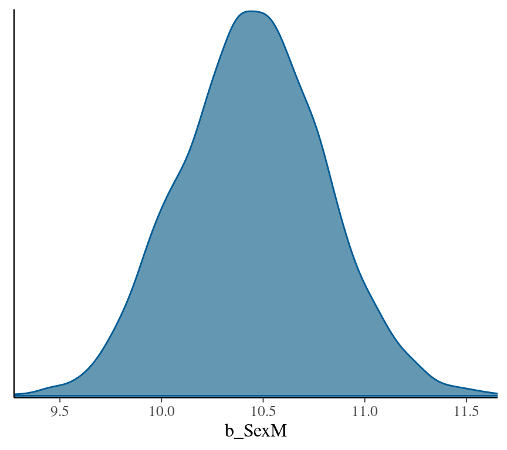

```r
mcmc_plot(brmfit_robust_p2, variable = "b_SexM",
          type = "dens")
```

## Summary

With a \(t\)-test parametrised like lm

- we can keep building up more complicated models
- equal variance, unequal variance, robust, \(\ldots\)

With brms can easily run MCMC-based sampling

- regression formula syntax bf(… ~ …)
- specify distributional assumptions with *family*

But default priors

- often flat or unrealistic
- can check by sampling from prior

But we can (should) specify sensible priors for fully Bayesian inference

- prior(…) function

\(\rightarrow\) Exercises 6